# STORMBREAKER: six practical workflows

This tutorial connects prepared input tables to fitted models, evaluation tables and plots. All data are synthetic. Each scenario is a separate packaged script that returns example_result and figures; scripts do not automatically export files or open a browser.

```r
library(stormbreaker)
source(system.file("examples", "scenarios", "01-binary.R",
  package = "stormbreaker", mustWork = TRUE))
figures$ROC
```

Replace the script name to run another scenario. The illustrated tutorial is also available through vignette(“stormbreaker-short-scenarios”).

## Prepare the input

Each row represents one patient and each predictor is a numeric feature.

| Input | Required columns | Meaning |
| --- | --- | --- |
| Binary development/evaluation | patient_id, outcome, gene_a, gene_b, gene_c | outcome is 0/1; 1 is the positive class |
| Survival development/evaluation | patient_id, time, event, gene_a, gene_b, gene_c | event is 1 for an observed event and 0 for censoring; declare the time unit |
| Prediction | patient_id and the fitted model’s required features | Outcomes are not needed |
| Explanation background | The model’s predictor columns | A declared development/reference cohort |

Replace the illustrative gene names with your prepared columns and declare them in predictors. Transpose a gene-by-sample expression matrix and align identifiers to clinical records before task construction. Raw sequencing processing, normalization, log transformation, identifier mapping and imputation are upstream steps. External features must use compatible definitions and preprocessing.

The first three rows of the packaged binary development cohort are:

| patient_id | outcome | gene_a | gene_b | gene_c |
| --- | --- | --- | --- | --- |
| DEV_B001 | 0 | 1.513 | -2.001 | -0.485 |
| DEV_B002 | 0 | 0.258 | 0.334 | 0.189 |
| DEV_B003 | 0 | 0.088 | 1.171 | 0.051 |

For repeated observations, assign a unique row identifier and declare the patient group:

```r
task <- bi_task(development, "analysis_id", "outcome", genes,
  group_col = "patient_id")
```

Supported resampling keeps each patient in one fold. This does not change row weights or automatically configure every native engine’s internal resampling. The tutorial CSVs use one row per independent patient.

## Follow the objects

| Object | Constructor | Contents |
| --- | --- | --- |
| data.frame | Prepared CSV/table | Identifiers, outcomes and numeric predictors |
| task | bi_task(), surv_task() | Data, column roles, units and declared horizons/thresholds |
| route | bi_pipeline(), surv_pipeline() | An unfitted selection/prediction specification |
| comparison | compare_cv(), run$comparison | Saved cross-validation evidence |
| fit | fit_final(), finished$fit | The reusable final model |
| prediction | predict_final() | New-sample predictions without outcomes |
| evaluation | eval_external() | ID-aligned outcomes, metrics, curves and status |
| views | clinical_plots() | Plots, separate captions and availability |

Final fitting does not replace CV. Prediction, result tables and clinical views do not train another model. SHAP adds an explanation calculation without refitting.

## 1. Start with binary classification

This scenario uses 120 development observations, Logistic regression and three folds. The small threshold grid is illustrative. plots=FALSE avoids an additional final fit during comparison; plots are drawn from the saved CV result.

```r
library(stormbreaker)

development <- read.csv(system.file("extdata", "demo-binary-development.csv",
  package = "stormbreaker"), check.names = FALSE)
genes <- c("gene_a", "gene_b", "gene_c")

run <- bi_run(development, outcome = "outcome", id = "patient_id",
  predictors = genes, models = "Logistic", folds = 3, seed = 42,
  decision_thresholds = c(.1, .2, .3, .5, .7), plots = FALSE)
comparison <- run$comparison
metrics <- result_table(comparison, metric = "roc_auc")
figures <- list(
  ROC = plot_roc(comparison),
  Calibration = plot_calib(comparison),
  DCA = plot_dca(comparison)
)
example_result <- list(input = development, run = run,
  comparison = comparison, metrics = metrics, figures = figures)

if (interactive()) print(figures$ROC)
```

run is the workflow object; run$comparison is the comparison. metrics contains the AUC result; figures includes ROC, calibration and decision curves.

| pipeline_id | metric | estimate | status | scope |
| --- | --- | --- | --- | --- |
| none__logistic | roc_auc | 0.654 | success | within_outer_assessment_fold |

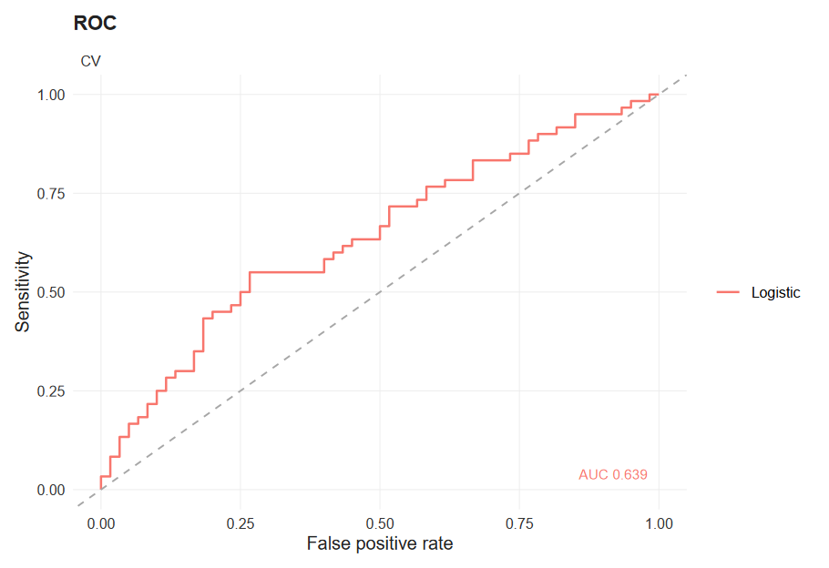

The ROC uses saved out-of-fold predictions and the existing fold-summary convention, not an apparent-training ROC. Access figures$Calibration and figures$DCA for the other views. Decision curves require declared thresholds; use clinically meaningful prespecified values rather than copying a demonstration grid into a study protocol.

## 2. Compare specified models

Logistic and Gaussian naive Bayes use the same candidate genes and outer folds. compare_cv() compares the declared routes; it does not choose a winner using an external test cohort.

```r
library(stormbreaker)

development <- read.csv(system.file("extdata", "demo-binary-development.csv",
  package = "stormbreaker"), check.names = FALSE)
genes <- c("gene_a", "gene_b", "gene_c")
task <- bi_task(development, "patient_id", "outcome", genes)
routes <- list(
  Logistic = bi_pipeline("Logistic"),
  NaiveBayes = bi_pipeline("NaiveBayes")
)
comparison <- compare_cv(task, routes, folds = 3, seed = 42, progress = FALSE)
metrics <- result_table(comparison, metric = "roc_auc")
figures <- list(
  Performance = plot_perf(comparison, metric = "roc_auc"),
  ROC = plot_roc(comparison)
)
example_result <- list(input = development, task = task, routes = routes,
  comparison = comparison, metrics = metrics, figures = figures)

if (interactive()) print(figures$Performance)
```

The output contains two metric rows and comparison plots:

| pipeline_id | metric | estimate | status |
| --- | --- | --- | --- |
| none__logistic | roc_auc | 0.654 | success |
| none__gaussian_naive_bayes__smooth1e-09 | roc_auc | 0.626 | success |

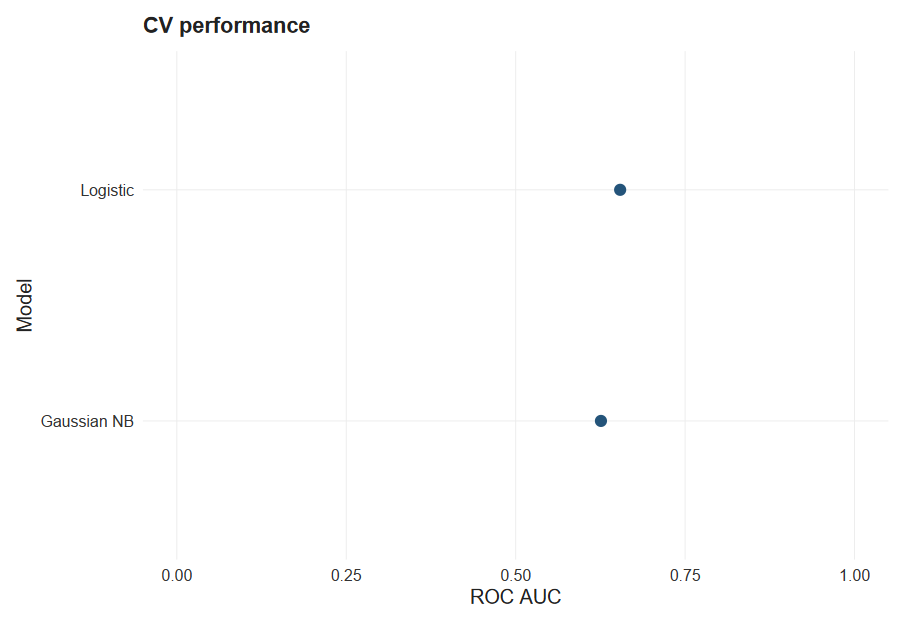

Inspect models(“binary”) before adding a method to routes. An omitted model list requests a much larger menu and can increase runtime and dependency requirements.

## 3. Evaluate one final model in two cohorts

The development table has 120 observations; validation cohorts A and B have 80 and 70. Their columns agree. finish_run() continues the selected Logistic route without repeating the complete candidate comparison; one final model predicts both cohorts.

```r
library(stormbreaker)

development <- read.csv(system.file("extdata", "demo-binary-development.csv",
  package = "stormbreaker"), check.names = FALSE)
validation_a <- read.csv(system.file("extdata", "demo-binary-external-a.csv",
  package = "stormbreaker"), check.names = FALSE)
validation_b <- read.csv(system.file("extdata", "demo-binary-external-b.csv",
  package = "stormbreaker"), check.names = FALSE)
genes <- c("gene_a", "gene_b", "gene_c")

run <- bi_run(development, outcome = "outcome", id = "patient_id",
  predictors = genes, models = "Logistic", folds = 3, seed = 42,
  decision_thresholds = c(.1, .2, .3, .5, .7), plots = FALSE)
finished <- finish_run(run, "Logistic",
  external = list(Validation_A = validation_a, Validation_B = validation_b),
  plots = TRUE)
views <- clinical_plots(finished)
metrics <- do.call(rbind, lapply(names(finished$evaluations), function(cohort) {
  result_table(finished$evaluations[[cohort]], metric = "roc_auc", cohort_label = cohort)
}))
figures <- list(ROC = views$plots$ROC)
example_result <- list(input = development,
  external = list(Validation_A = validation_a, Validation_B = validation_b),
  run = run, finished = finished, views = views, metrics = metrics, figures = figures)

if (interactive()) print(figures$ROC)
```

| Location | Contents |
| --- | --- |
| finished$fit | The final model |
| finished$genes | Stage-wise feature tables |
| finished$predictions$Validation_A | Original model predictions |
| finished$evaluated_predictions$Validation_A | Predictions corresponding to reported metrics |
| finished$evaluations$Validation_A | The evaluation object |
| views$plots, views$status | Clinical plots and availability |

The first three original predictions and cohort-level metrics are:

| patient_id | probability |
| --- | --- |
| EXTA_B001 | 0.601 |
| EXTA_B002 | 0.493 |
| EXTA_B003 | 0.332 |

| cohort_label | metric | estimate | status |
| --- | --- | --- | --- |
| Validation_A | roc_auc | 0.541 | success |
| Validation_B | roc_auc | 0.707 | success |

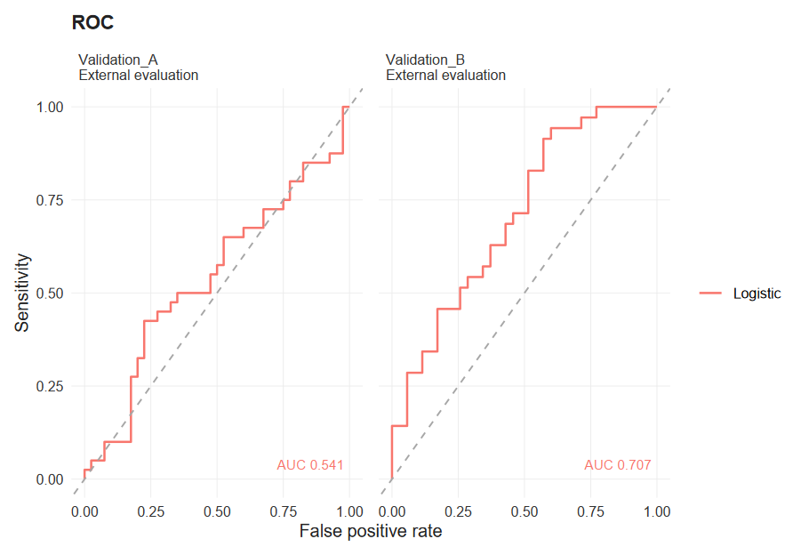

Pass a comparison or evaluation object, not the completed bundle, to result_table():

```r
result_table(finished$evaluations$Validation_A, metric = "roc_auc")
```

### Save files when needed

The following code is not executed automatically. Use a new directory to retain previous results:

```r
export_run(finished, "analysis-output-new")
clinical_report(views, "analysis-output-new/clinical-report.html")
ggplot2::ggsave("analysis-output-new/external-roc.pdf", figures$ROC,
  width = 7, height = 5)
saveRDS(finished$fit, "analysis-output-new/final-model.rds")
```

Exports include comparison/feature tables, a cohort index, original/evaluation predictions, metrics and available plots. Review patient-level predictions, explanations and saved models before sharing. Without external outcomes, predict only; ROC, calibration and accuracy cannot be evaluated.

## 4. Predict survival risk and horizon probabilities

This scenario evaluates Cox risk ranking and six-month survival predictions. It uses 160 development observations and 100 validation observations.

| patient_id | time | event | gene_a | gene_b | gene_c |
| --- | --- | --- | --- | --- | --- |
| SDEV_P001 | 11.233 | 1 | 1.371 | -0.176 | -0.485 |
| SDEV_P002 | 6.996 | 1 | -0.565 | -1.072 | 0.189 |
| SDEV_P003 | 12.005 | 0 | 0.363 | 0.163 | 0.051 |

Declare time_unit=“month” with prediction_horizon=6. An event is coded as 1 and censoring as 0; follow-up time must not be discarded as though this were an ordinary binary endpoint.

```r
library(stormbreaker)

development <- read.csv(system.file("extdata", "demo-survival-development.csv",
  package = "stormbreaker"), check.names = FALSE)
validation <- read.csv(system.file("extdata", "demo-survival-external.csv",
  package = "stormbreaker"), check.names = FALSE)
genes <- c("gene_a", "gene_b", "gene_c")
task <- surv_task(development, "patient_id", "time", "event", genes,
  time_unit = "month", prediction_horizon = 6,
  decision_thresholds = c(.1, .2, .3, .5, .7))
route <- surv_pipeline("Cox")
cv <- run_cv(task, route, folds = 3, seed = 42, progress = FALSE)
fit <- fit_final(task, route)
prediction <- predict_final(fit, validation[c("patient_id", genes)], "patient_id")
endpoint <- surv_endpoint(validation, "patient_id", "time", "event",
  time_unit = "month", prediction_horizon = 6)
evaluation <- eval_external(prediction, endpoint)
metrics <- result_table(evaluation, metric = "harrell_c", cohort_label = "Validation")
horizon_metrics <- do.call(rbind, lapply(c("time_auc", "ipcw_brier"), function(metric) {
  result_table(evaluation, metric = metric, cohort_label = "Validation")
}))
figures <- list(Calibration = plot_calib(evaluation), DCA = plot_dca(evaluation))
example_result <- list(input = development, external = validation, task = task,
  cv = cv, fit = fit, prediction = prediction, endpoint = endpoint,
  evaluation = evaluation, metrics = metrics, horizon_metrics = horizon_metrics, figures = figures)

if (interactive()) print(figures$Calibration)
```

Predictions retain risk and survival probability. Concordance and horizon-specific metrics are separate tables; the latter preserve the time and unit.

| patient_id | risk | survival_probability | prediction_horizon | time_unit |
| --- | --- | --- | --- | --- |
| SEXT_P001 | -0.576 | 0.830 | 6 | month |
| SEXT_P002 | 0.118 | 0.688 | 6 | month |
| SEXT_P003 | -0.426 | 0.805 | 6 | month |

| metric | estimate | status |
| --- | --- | --- |
| harrell_c | 0.641 | success |

| metric | estimate | status | prediction_horizon | time_unit |
| --- | --- | --- | --- | --- |
| time_auc | 0.687 | success | 6 | month |
| ipcw_brier | 0.183 | success | 6 | month |

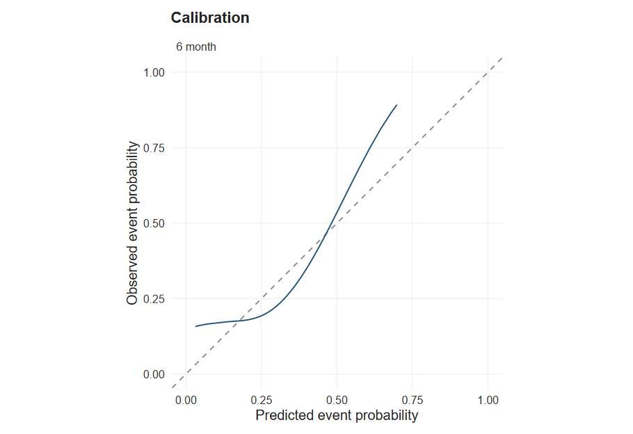

A risk score is not a probability. survival_probability is the probability of remaining alive at the specified horizon; decision curves use its event-risk complement. Time-dependent AUC differs from ordinary binary ROC. Without a prediction horizon, absolute-probability calibration and horizon-specific decision curves are unavailable.

## 5. Select features and inspect native diagnostics

The ordered route is Lasso selection followed by Logistic prediction. It needs glmnet, installed by the user. capture_diagnostics=TRUE retains native evidence during fitting rather than refitting when a plot is requested.

```r
library(stormbreaker)

development <- read.csv(system.file("extdata", "demo-binary-development.csv",
  package = "stormbreaker"), check.names = FALSE)
genes <- c("gene_a", "gene_b", "gene_c")
task <- bi_task(development, "patient_id", "outcome", genes)
route <- bi_pipeline(c("Lasso", "Logistic"))
fit <- fit_final(task, route, capture_diagnostics = TRUE)
diagnostics <- plots(fit)
retained_genes <- data.frame(gene = fit$required_features)
coefficients <- model_coefs(fit, reference_data = development[genes])
figures <- c(diagnostics$plots, list(Coefficients = plot_coefs(coefficients)))
example_result <- list(input = development, task = task, route = route, fit = fit,
  genes = retained_genes, diagnostics = diagnostics,
  coefficients = coefficients, figures = figures)

if (interactive()) print(figures$Coefficients)
```

fit$required_features lists the features needed for prediction. Available native views are in diagnostics$plots; the example shows retained genes and the selection CV curve:

| gene |
| --- |
| gene_a |

| plot |
| --- |
| logistic: linear_coefficients_diagnostic |
| selector_1 |
| selector_1_coefficient_path |
| selector_1_cv |
| Coefficients |

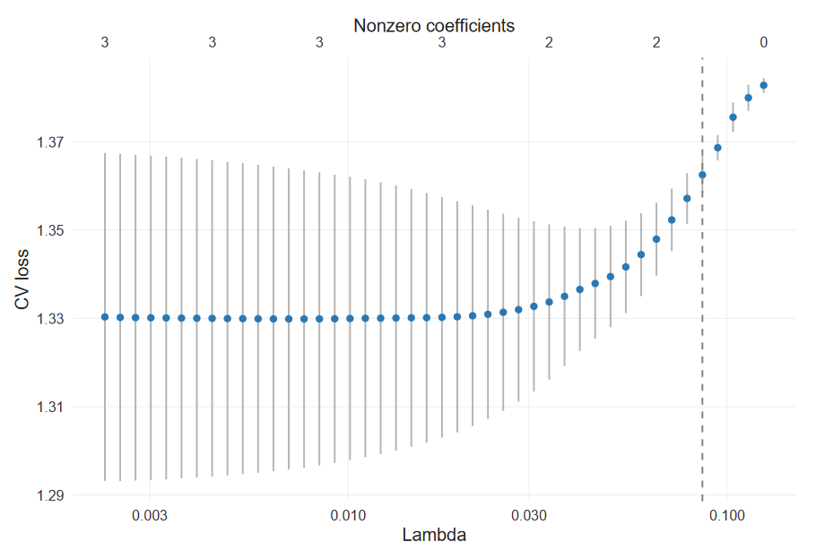

The coefficient path and final-model coefficients are separate views. Inspect diagnostics$unavailable when evidence is absent; an older saved fit cannot supply a path it never retained. selected_genes() applies to independent method-analysis results rather than arbitrary fitted model objects.

Additional routes can be defined explicitly:

```r
surv_pipeline("pamr", selector = surv_selector("Ridge"))
bi_pipeline(c("mRMR", "xgboost_linear"))
bi_pipeline(c("RF", "mclustda_bic"))
```

These are unfitted specifications requiring suitable data and optional engines.

### Extract diagnostics with short names

| Evidence | Interface |
| --- | --- |
| Regularization paths and saved CV | path_diag() |
| Forest importance, tree size and supported OOB evidence | forest_diag() |
| PAMR centroids | pamr_diag() |
| mclustDA components | mclust_diag() |
| SVM, PLS and naive Bayes structure | svm_diag(), pls_diag(), nb_diag() |
| Complete availability table | native_diag(fit, complete=TRUE)$status |
| Diagnostic plotting | plot_diag() |

The following fits a Lasso predictor and extracts its own CV curve and path. It is different from the Logistic predictor downstream of Lasso selection.

|  | lambda | mean_deviance | standard_error | nonzero | mean_value | selected |
| --- | --- | --- | --- | --- | --- | --- |
| s0 | 0.1248 | 1.3889 | 0.0020 | 0 | 1.3889 | TRUE |
| s1 | 0.1137 | 1.3924 | 0.0036 | 1 | 1.3924 | FALSE |
| s2 | 0.1036 | 1.3914 | 0.0089 | 1 | 1.3914 | FALSE |

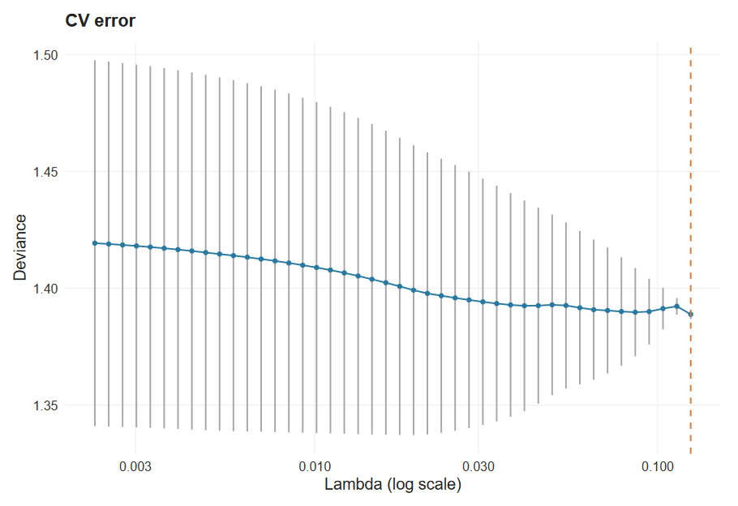

```r
library(stormbreaker)

development <- read.csv(system.file("extdata", "demo-binary-development.csv",
  package = "stormbreaker"), check.names = FALSE)
genes <- c("gene_a", "gene_b", "gene_c")
task <- bi_task(development, "patient_id", "outcome", genes)
fit <- fit_final(task, bi_pipeline("Lasso"), capture_diagnostics = TRUE)
cv <- path_diag(fit, type = "cv_curve")
path <- path_diag(fit, type = "coefficient_path")
native <- native_diag(fit, complete = TRUE)
figures <- list(CV = plot_diag(cv), Path = plot_diag(path))
example_result <- list(input = development, task = task, fit = fit,
  cv = cv, path = path, native = native, figures = figures)

if (interactive()) print(figures$CV)
```

The full mapping is in guides/specialty-name-map.csv and the accompanying specialty-short-names.md guide. Original names and existing aliases remain valid. Export generated algorithm plots through a completed workflow:

```r
r <- bi_run(development, outcome="outcome", id="patient_id",
  predictors=genes, models="Lasso", plots=FALSE)
done <- finish_run(r, "Lasso", plots=TRUE)
export_run(done, "native-plots-new")
write.csv(path_diag(done$fit, "cv_curve")$table,
  "native-plots-new/lasso-cv.csv", row.names=FALSE)
```

figures.csv maps exported PDFs to plot names. Export native diagnostic tables separately when required. An internal tuning curve does not replace out-of-fold or external evaluation of the complete route.

## 6. Explain individual predictions

The example first prepares a Logistic model. For an existing model, load the saved fit instead. Query data contain only identifiers and features; background features come from development data.

```r
library(stormbreaker)

development <- read.csv(system.file("extdata", "demo-binary-development.csv",
  package = "stormbreaker"), check.names = FALSE)
validation <- read.csv(system.file("extdata", "demo-binary-external-a.csv",
  package = "stormbreaker"), check.names = FALSE)
genes <- c("gene_a", "gene_b", "gene_c")

task <- bi_task(development, "patient_id", "outcome", genes)
fit <- fit_final(task, bi_pipeline("Logistic"))
query <- validation[1:8, c("patient_id", genes)]
background <- development[genes]
shap <- model_shap(fit, query, "patient_id", background_data = background,
  permutations = 16, background_n = 12, seed = 42)
figures <- list(
  Importance = plot_shap_imp(shap),
  Beeswarm = plot_shap(shap, feature_values = query, id_col = "patient_id"),
  Dependence = plot_shap_dep(shap, "gene_a", query, "patient_id"),
  Waterfall = plot_shap_one(shap, row = 1)
)
example_result <- list(input = development, task = task, fit = fit,
  query = query, background = background, shap = shap, figures = figures)

if (interactive()) print(figures$Beeswarm)
```

shap$contributions is an eight-sample by three-feature matrix. The reference value plus a row’s contributions reconstructs that sample’s saved model score. Here model_shap() explains positive-class probabilities using an approximate permutation estimator, not exact TreeSHAP. Sixteen permutations keep the example small; assess approximation stability for your application.

|  | gene_a | gene_b | gene_c |
| --- | --- | --- | --- |
| EXTA_B001 | 0.1917 | -0.0428 | -0.0072 |
| EXTA_B002 | -0.0496 | 0.0839 | -0.0009 |
| EXTA_B003 | -0.1016 | 0.0054 | -0.0314 |

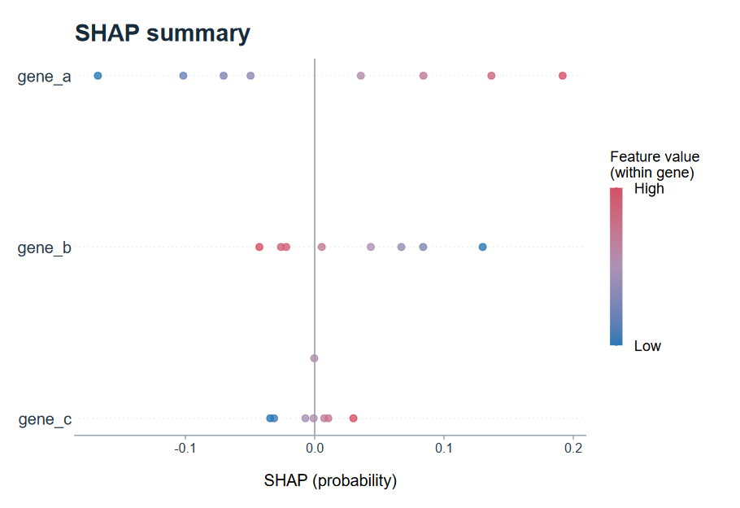

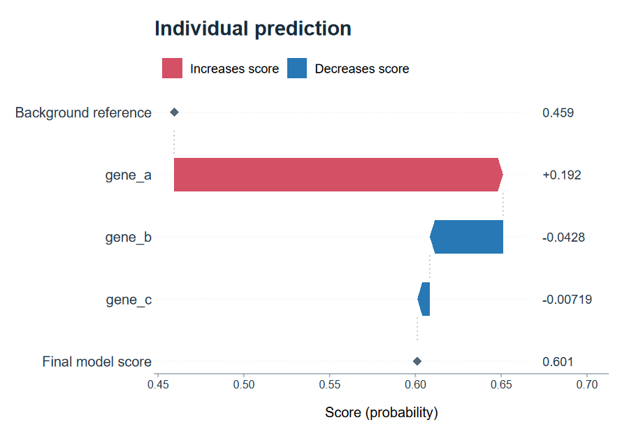

Use figures$Importance and figures$Dependence for the other views. SHAP describes this model and background, not causal effects or automatically selected clinical thresholds.

## Troubleshooting

| Symptom | Inspect |
| --- | --- |
| Invalid task data | Column names, endpoint codes, missing values and identifiers |
| Failed fit | fit$status and the recorded error; run$issues or finished$issues |
| Missing clinical view | views$status |
| Missing native diagnostic | diagnostics$unavailable and retained fitting evidence |
| Failed evaluation | evaluation$status, IDs, required features, horizon and units |
| Function-name collision | A qualified name such as stormbreaker::fit_final() |

Packaged paths are obtained through system.file(). Replace the simulated input with prepared study data while retaining the declared object types and input roles.